# Interprétation de l’IDB

### Guide pour l’interprétation

#### **Interprétation des cartes**

Les cartes présentent la variation en probabilité d’occurrence entre la première et la dernière année mesurée pour une espèce choisie.

- Une différence positive signifie que l’espèce a connu une croissance dans la cellule
- Une différence négative signifie que l’espèce a connu un déclin dans la cellule

Dans le cas où “Toutes les espèces” sont sélectionnées, la carte présente la variation moyenne de toutes les espèces.

#### **Interprétation de l’indice**

L’indicateur permet de représenter le changement moyen dans les aires de distribution des espèces étudiées à l’aide d’un seul chiffre.

Un indicateur ayant une valeur x entre 0 et 1 (excluant 1) signifierait que les aires de distribution des espèces étudiées ont diminué en moyenne de (1-x)%.

- Par exemple, si l’indicateur a un valeur de 0.8, cela signifie que les aires de distribution des espèces ont diminué en moyenne de 20%.

Un indicateur de 1 signifierait quand à lui que la taille des aires de distribution des espèces n’ont en moyenne pas variées, ce qui ne veut pas dire pour autant qu’il n’y a pas eu de variation!

Un indicateur ayant une valeur x au-dessus de 1 signifierait que la taille des aires de distribution des espèces a varié en moyenne de (x-1)%

- Par exemple, si l’indicateur a un valeur de 1.2, cela signifie que les aires de distribution des espèces ont augmenté en moyenne de 20%.

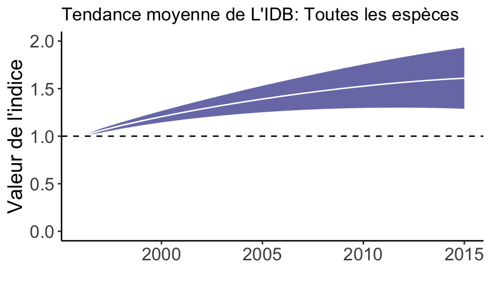

On peut donc conclure que la taille des aires de distribution des espèces a augmenté en moyenne de 60%.